# Covid-19 Analysis and Visualizations

# Packages

```python
import pandas as pd
import numpy as np
import plotly.express as px
import plotly.graph_objects as go
import matplotlib.pyplot as plt
import seaborn as sns
```

# Data Exploration

```python
df_global = pd.read_csv("current-data-on-the-geographic-distribution-of-covid-19-cases-worldwide.csv")
```

```python
df_global.head(2)
```

|  | daterep | day | month | year | cases | deaths | countriesandterritories | geoid | countryterritorycode | popdata2018 |
| --- | --- | --- | --- | --- | --- | --- | --- | --- | --- | --- |
| 0 | 2020-04-05 | 5 | 4 | 2020 | 35 | 1 | Afghanistan | AF | AFG | 37172386.0 |
| 1 | 2020-04-04 | 4 | 4 | 2020 | 0 | 0 | Afghanistan | AF | AFG | 37172386.0 |

```python
len(df_global)
```

```
8905
```

```python
df_global.countriesandterritories = df_global.countriesandterritories.replace('CuraÃ§ao', 'Curacao')
```

## Divide Countries by Continent

```python
df_global['Continent'] = ''
df_global['Continent'][(df_global.countriesandterritories == 'Afghanistan') |
(df_global.countriesandterritories == 'Armenia') | (df_global.countriesandterritories == 'Azerbaijan') |
(df_global.countriesandterritories == 'Bahrain') | (df_global.countriesandterritories == 'Bangladesh') |
(df_global.countriesandterritories == 'Bhutan') | (df_global.countriesandterritories == 'Brunei_Darussalam') |
(df_global.countriesandterritories == 'Cambodia') | (df_global.countriesandterritories == 'Oman') |
(df_global.countriesandterritories == 'Cases_on_an_international_conveyance_Japan') |
(df_global.countriesandterritories == 'China') | (df_global.countriesandterritories == 'Egypt') |
(df_global.countriesandterritories == 'Georgia') | (df_global.countriesandterritories == 'India') |
(df_global.countriesandterritories == 'Indonesia') | (df_global.countriesandterritories == 'Iran') |
(df_global.countriesandterritories == 'Iraq') | (df_global.countriesandterritories == 'Israel') |
(df_global.countriesandterritories == 'Japan') | (df_global.countriesandterritories == 'Jordan') |
(df_global.countriesandterritories == 'Kazakhstan') | (df_global.countriesandterritories == 'Kuwait') |
(df_global.countriesandterritories == 'Kyrgyzstan') | (df_global.countriesandterritories == 'Laos') |
(df_global.countriesandterritories == 'Lebanon') | (df_global.countriesandterritories == 'Malaysia') |
(df_global.countriesandterritories == 'Maldives') | (df_global.countriesandterritories == 'Mongolia') |
(df_global.countriesandterritories == 'Myanmar') | (df_global.countriesandterritories == 'Nepal') |
(df_global.countriesandterritories == 'Pakistan') | (df_global.countriesandterritories == 'Palestine') |
(df_global.countriesandterritories == 'Philippines') | (df_global.countriesandterritories == 'Qatar') |
(df_global.countriesandterritories == 'Russia') | (df_global.countriesandterritories == 'Saudi_Arabia') |
(df_global.countriesandterritories == 'Singapore') | (df_global.countriesandterritories == 'South_Korea') |
(df_global.countriesandterritories == 'Sri_Lanka') | (df_global.countriesandterritories == 'Syria') |
(df_global.countriesandterritories == 'Taiwan') | (df_global.countriesandterritories == 'Thailand') |
(df_global.countriesandterritories == 'Timor_Leste') | (df_global.countriesandterritories == 'Turkey') |
(df_global.countriesandterritories == 'United_Arab_Emirates') | (df_global.countriesandterritories == 'Vietnam') |
(df_global.countriesandterritories == 'Uzbekistan')] = 'Asia'

df_global['Continent'][(df_global.countriesandterritories == 'Albania') |
(df_global.countriesandterritories == 'Andorra') | (df_global.countriesandterritories == 'Austria') |
(df_global.countriesandterritories == 'Azerbaijan') | (df_global.countriesandterritories == 'Belarus') |
(df_global.countriesandterritories == 'Belgium') | (df_global.countriesandterritories == 'Bosnia_and_Herzegovina')
| (df_global.countriesandterritories == 'Bulgaria') | (df_global.countriesandterritories == 'Croatia') |
(df_global.countriesandterritories == 'Cyprus') | (df_global.countriesandterritories == 'Czech_Republic') |
(df_global.countriesandterritories == 'Denmark') | (df_global.countriesandterritories == 'Estonia') |
(df_global.countriesandterritories == 'Faroe_Islands') | (df_global.countriesandterritories == 'Finland') |
(df_global.countriesandterritories == 'France') | (df_global.countriesandterritories == 'Georgia') |
(df_global.countriesandterritories == 'Germany') | (df_global.countriesandterritories == 'Gibraltar') |
(df_global.countriesandterritories == 'Greece') | (df_global.countriesandterritories == 'Guernsey') |
(df_global.countriesandterritories == 'Holy_See') | (df_global.countriesandterritories == 'Hungary') |
(df_global.countriesandterritories == 'Iceland') | (df_global.countriesandterritories == 'Ireland') |
(df_global.countriesandterritories == 'Isle_of_Man') | (df_global.countriesandterritories == 'Italy') |
(df_global.countriesandterritories == 'Jersey') | (df_global.countriesandterritories == 'Kazakhstan') |
(df_global.countriesandterritories == 'Kosovo') | (df_global.countriesandterritories == 'Latvia') |
(df_global.countriesandterritories == 'Liechtenstein') | (df_global.countriesandterritories == 'Lithuania') |
(df_global.countriesandterritories == 'Luxembourg') | (df_global.countriesandterritories == 'Malta') |
(df_global.countriesandterritories == 'Moldova') | (df_global.countriesandterritories == 'Monaco') |
(df_global.countriesandterritories == 'Montenegro') | (df_global.countriesandterritories == 'Netherlands') |
(df_global.countriesandterritories == 'North_Macedonia') | (df_global.countriesandterritories == 'Norway') |
(df_global.countriesandterritories == 'Poland') | (df_global.countriesandterritories == 'Portugal') |
(df_global.countriesandterritories == 'Romania') | (df_global.countriesandterritories == 'Russia') |
(df_global.countriesandterritories == 'San_Marino') | (df_global.countriesandterritories == 'Slovakia') |
(df_global.countriesandterritories == 'Slovenia') | (df_global.countriesandterritories == 'Spain') |
(df_global.countriesandterritories == 'Sweden') | (df_global.countriesandterritories == 'Switzerland') |
(df_global.countriesandterritories == 'Turkey') | (df_global.countriesandterritories == 'Ukraine') |
(df_global.countriesandterritories == 'United_Kingdom') | (df_global.countriesandterritories == 'Serbia')] = 'Europe'

df_global['Continent'][(df_global.countriesandterritories == 'Algeria') |
(df_global.countriesandterritories == 'Angola') | (df_global.countriesandterritories == 'Benin') |
(df_global.countriesandterritories == 'Botswana') | (df_global.countriesandterritories == 'Burkina_Faso') |
(df_global.countriesandterritories == 'Burundi') | (df_global.countriesandterritories == 'Cameroon') |
(df_global.countriesandterritories == 'Cape_Verde') |
(df_global.countriesandterritories == 'Central_African_Republic') | (df_global.countriesandterritories == 'Chad')
| (df_global.countriesandterritories == 'Congo') | (df_global.countriesandterritories == 'Cote_dIvoire') |
(df_global.countriesandterritories == 'Democratic_Republic_of_the_Congo') |
(df_global.countriesandterritories == 'Djibouti') | (df_global.countriesandterritories == 'Egypt') |
(df_global.countriesandterritories == 'Equatorial_Guinea') | (df_global.countriesandterritories == 'Eritrea') |
(df_global.countriesandterritories == 'Eswatini') | (df_global.countriesandterritories == 'Ethiopia') |
(df_global.countriesandterritories == 'Gabon') | (df_global.countriesandterritories == 'Gambia') |
(df_global.countriesandterritories == 'Ghana') | (df_global.countriesandterritories == 'Guinea') |
(df_global.countriesandterritories == 'Guinea_Bissau') | (df_global.countriesandterritories == 'Kenya') |
(df_global.countriesandterritories == 'Liberia') | (df_global.countriesandterritories == 'Libya') |
(df_global.countriesandterritories == 'Madagascar') | (df_global.countriesandterritories == 'Malawi') |
(df_global.countriesandterritories == 'Mali') | (df_global.countriesandterritories == 'Mauritania') |
(df_global.countriesandterritories == 'Mauritius') | (df_global.countriesandterritories == 'Morocco') |
(df_global.countriesandterritories == 'Mozambique') | (df_global.countriesandterritories == 'Namibia') |
(df_global.countriesandterritories == 'Niger') | (df_global.countriesandterritories == 'Nigeria') |
(df_global.countriesandterritories == 'Rwanda') | (df_global.countriesandterritories == 'South_Africa')|
(df_global.countriesandterritories == 'Senegal') | (df_global.countriesandterritories == 'Seychelles') |
(df_global.countriesandterritories == 'Sierra_Leone') | (df_global.countriesandterritories == 'Somalia') |
(df_global.countriesandterritories == 'Sudan') | (df_global.countriesandterritories == 'Togo') |
(df_global.countriesandterritories == 'Tunisia') | (df_global.countriesandterritories == 'Uganda') |
(df_global.countriesandterritories == 'United_Republic_of_Tanzania') |
(df_global.countriesandterritories == 'Zambia') | (df_global.countriesandterritories == 'Zimbabwe')] = 'Africa'

df_global['Continent'][(df_global.countriesandterritories == 'Anguilla') |
(df_global.countriesandterritories == 'Antigua_and_Barbuda') | (df_global.countriesandterritories == 'Bahamas') |
(df_global.countriesandterritories == 'Barbados') | (df_global.countriesandterritories == 'Belize') |
(df_global.countriesandterritories == 'Bermuda') | (df_global.countriesandterritories == 'British_Virgin_Islands')
| (df_global.countriesandterritories == 'Canada') | (df_global.countriesandterritories == 'Cayman_Islands') |
(df_global.countriesandterritories == 'Costa_Rica') | (df_global.countriesandterritories == 'Cuba') |
(df_global.countriesandterritories == 'Dominica') | (df_global.countriesandterritories == 'Dominican_Republic')
| (df_global.countriesandterritories == 'El_Salvador') | (df_global.countriesandterritories == 'Greenland') |
(df_global.countriesandterritories == 'Grenada') | (df_global.countriesandterritories == 'Guatemala') |
(df_global.countriesandterritories == 'Haiti') | (df_global.countriesandterritories == 'Honduras') |
(df_global.countriesandterritories == 'Jamaica') | (df_global.countriesandterritories == 'Mexico') |
(df_global.countriesandterritories == 'Montserrat') | (df_global.countriesandterritories == 'Nicaragua') |
(df_global.countriesandterritories == 'Panama') | (df_global.countriesandterritories == 'Puerto_Rico') |
(df_global.countriesandterritories == 'Oman') | (df_global.countriesandterritories == 'Saint_Barthelemy') |
(df_global.countriesandterritories == 'Saint_Kitts_and_Nevis') |
(df_global.countriesandterritories == 'Saint_Lucia') | (df_global.countriesandterritories == 'Sint_Maarten') |
(df_global.countriesandterritories == 'Saint_Vincent_and_the_Grenadines') |
(df_global.countriesandterritories == 'Turks_and_Caicos_islands') |
(df_global.countriesandterritories == 'United_States_of_America') |
(df_global.countriesandterritories == 'United_States_Virgin_Islands')] = 'North America'

df_global['Continent'][(df_global.countriesandterritories == 'Argentina') |
(df_global.countriesandterritories == 'Aruba') | (df_global.countriesandterritories == 'Bolivia') |
(df_global.countriesandterritories == 'Uruguay') |
(df_global.countriesandterritories == 'Bonaire, Saint Eustatius and Saba')
| (df_global.countriesandterritories == 'Brazil') | (df_global.countriesandterritories == 'Chile') |
(df_global.countriesandterritories == 'Colombia') | (df_global.countriesandterritories == 'Curacao') |
(df_global.countriesandterritories == 'Ecuador') | (df_global.countriesandterritories == 'Guyana') |
(df_global.countriesandterritories == 'Falkland_Islands_(Malvinas)') |
(df_global.countriesandterritories == 'Paraguay') | (df_global.countriesandterritories == 'Peru') |
(df_global.countriesandterritories == 'Suriname') | (df_global.countriesandterritories == 'Trinidad_and_Tobago') |
(df_global.countriesandterritories == 'Venezuela')] = 'South America'

df_global['Continent'][(df_global.countriesandterritories == 'Australia') |
(df_global.countriesandterritories == 'Fiji') | (df_global.countriesandterritories == 'French_Polynesia') |
(df_global.countriesandterritories == 'Guam') | (df_global.countriesandterritories == 'New_Caledonia') |
(df_global.countriesandterritories == 'New_Zealand') | (df_global.countriesandterritories == 'Papua_New_Guinea')
| (df_global.countriesandterritories == 'Northern_Mariana_Islands')] = 'Australia'
```

[output not shown]

# Analysis

```python
df_continent = df_global.groupby(['Continent', 'countriesandterritories'])\
.agg({"cases": "sum", "deaths": "sum"}).sort_values('cases', ascending = False).reset_index()
```

```python
df_continent_timeseries = df_global.groupby(['Continent', 'daterep']).sum().reset_index()
```

## Asia

### Bar Chart

```python
asia = df_continent[df_continent.Continent == "Asia"]
fig = px.bar(asia, x = "countriesandterritories", y = "cases", color = "deaths",
             log_y = True, labels = {"countriesandterritories" : ""})
fig.show()
```

[interactive chart not shown]

China has the highest number of cases in Asia, followed by Iran, South Korea, Israel, and Malaysia. However, the number of deaths in Iran surpasses China. Although Indonesia has less cases than many Asian countries, the number of deaths is higher.

### Time Series

```python
time_series_asia = df_continent_timeseries[df_continent_timeseries.Continent == "Asia"]
fig = go.Figure()
fig.add_trace(go.Scatter(x = time_series_asia.daterep, y = time_series_asia.cases,
                         mode='lines', name='number of cases'))
fig.add_trace(go.Scatter(x = time_series_asia.daterep, y = time_series_asia.deaths,
                         mode = 'lines', name = 'number of deaths'))
fig.show()
```

[interactive chart not shown]

There is a spike in number of cases in Asia on February 13th, 2020.

- On this date, China reported a large number of increase in the COVID-19 cases in Hubei Province.
- See source: https://www.scmp.com/news/china/society/article/3050354/coronavirus-hubei-province-reports-sharp-spike-new-confirmed

## Europe

### Bar Chart

```python
europe = df_continent[df_continent.Continent == "Europe"]
fig = px.bar(europe, x = "countriesandterritories", y = "cases", color = "deaths",
             log_y = True, labels = {"countriesandterritories" : ""})
fig.show()
```

[interactive chart not shown]

The number of cases in Italy is the highest among all European countries followed by Germany, France, United Kingdom, and Turkey. The number of COVID-19 deaths in Italy far surpassed the deaths in other European countries. Although the Netherlands has less cases than Belgium, Switzerland, and Turkey, the number of deaths in the country is higher.

### Time Series

```python
time_series_europe = df_continent_timeseries[df_continent_timeseries.Continent == "Europe"]
fig = go.Figure()
fig.add_trace(go.Scatter(x = time_series_europe.daterep, y = time_series_europe.cases,
                         mode='lines', name='number of cases'))
fig.add_trace(go.Scatter(x = time_series_europe.daterep, y = time_series_europe.deaths,
                         mode = 'lines', name = 'number of deaths'))
fig.show()
```

[interactive chart not shown]

The number of cases in Europe started increasing on March 4th, 2020. It seems like there is no peak yet and is still increasing as of April 5th, 2020.

## Africa

### Bar Chart

```python
africa = df_continent[df_continent.Continent == "Africa"]
fig = px.bar(africa, x = "countriesandterritories", y = "cases", color = "deaths",
             log_y = True, labels = {"countriesandterritories" : ""})
fig.show()
```

[interactive chart not shown]

On the African continent, South Africa has the highest number of COVID-19 cases even though Algeria has significantly more deaths. Most of the countries in Africa has below 500 COVID-19 cases and less than 100 deaths. This could be due to the lack of testing available in these countries.

- See Article https://abcnews.go.com/International/africa-faces-uphill-battle-coronavirus-pandemic-fragile-health/story?id=70285430
  - According to the article, "Algeria ranks among the least prepared countries in the world to respond to a health crisis in the 2019 Johns Hopkins Global Health Security Index." and that "several factors could hinder the containment and mitigation measures in the African nations, in particular the region's fragile health systems, poor access to safe water and sanitation facilities, and the large and densely populated urban informal settlements.".

### Time Series

```python
time_series_africa = df_continent_timeseries[df_continent_timeseries.Continent == "Africa"]
fig = go.Figure()
fig.add_trace(go.Scatter(x = time_series_africa.daterep, y = time_series_africa.cases,
                         mode='lines', name='number of cases'))
fig.add_trace(go.Scatter(x = time_series_africa.daterep, y = time_series_africa.deaths,
                         mode = 'lines', name = 'number of deaths'))
# fig.update_layout(yaxis_type="log")
fig.show()
```

[interactive chart not shown]

There is a stark increase in the number of cases on the African continent from April 4th to April 5th, 2020.

## North America

### Bar Chart

```python
northamerica = df_continent[df_continent.Continent == "North America"]
fig = px.bar(northamerica, x = "countriesandterritories", y = "cases", color = "deaths",
             log_y = True, labels = {"countriesandterritories" : ""})
fig.show()
```

[interactive chart not shown]

On the North American continent, the United States of America has the highest number of COVID-19 cases as well as highest number of COVID-19 deaths, followed by Canada, Mexico, Panama, and Dominican Republic.

### Time Series

```python
time_series_na = df_continent_timeseries[df_continent_timeseries.Continent == "North America"]
fig = go.Figure()
fig.add_trace(go.Scatter(x = time_series_na.daterep, y = time_series_na.cases,
                         mode='lines', name='number of cases'))
fig.add_trace(go.Scatter(x = time_series_na.daterep, y = time_series_na.deaths,
                         mode = 'lines', name = 'number of deaths'))
# fig.update_layout(yaxis_type="log")
fig.show()
```

[interactive chart not shown]

The number of COVID-19 cases in North America has been increasing from March 16th, 2020 to April 5th, 2020.

## South America

### Bar Chart

```python
southamerica = df_continent[df_continent.Continent == "South America"]
fig = px.bar(southamerica, x = "countriesandterritories", y = "cases", color = "deaths",
             log_y = True, labels = {"countriesandterritories" : ""})
fig.show()
```

[interactive chart not shown]

### Time Series

```python
time_series_sa = df_continent_timeseries[df_continent_timeseries.Continent == "South America"]
fig = go.Figure()
fig.add_trace(go.Scatter(x = time_series_sa.daterep, y = time_series_sa.cases,
                         mode='lines', name='number of cases'))
fig.add_trace(go.Scatter(x = time_series_sa.daterep, y = time_series_sa.deaths,
                         mode = 'lines', name = 'number of deaths'))
# fig.update_layout(yaxis_type="log")
fig.show()
```

[interactive chart not shown]

## Australia

### Bar Chart

```python
australia = df_continent[df_continent.Continent == "Australia"]
fig = px.bar(australia, x = "countriesandterritories", y = "cases", color = "deaths",
             log_y = True, labels = {"countriesandterritories" : ""})
fig.show()
```

[interactive chart not shown]

### Time Series

```python
time_series_australia = df_continent_timeseries[df_continent_timeseries.Continent == "Australia"]
fig = go.Figure()
fig.add_trace(go.Scatter(x = time_series_australia.daterep, y = time_series_australia.cases,
                         mode='lines', name='number of cases'))
fig.add_trace(go.Scatter(x = time_series_australia.daterep, y = time_series_australia.deaths,
                         mode = 'lines', name = 'number of deaths'))
fig.show()
```

[interactive chart not shown]

## Comparison Across Continents

```python
df_global_continent = df_global.groupby(['Continent', 'daterep']).sum().reset_index()
fig1 = px.line(df_global_continent, x = 'daterep', y = 'cases', color = 'Continent')
fig2 = px.line(df_global_continent, x = 'daterep', y = 'deaths', color = 'Continent')
fig1.show()
fig2.show()
```

[interactive chart not shown]

### Poisson Distribution

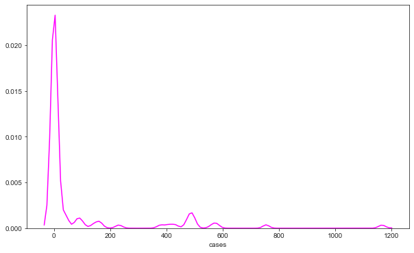

```python
africa = df_global_continent[df_global_continent.Continent == "Africa"]
sns.set_style('ticks')
fig, ax = plt.subplots()
fig.set_size_inches(10, 6)
sns.distplot(africa.cases, hist = False, color = "magenta", ax = ax)
```

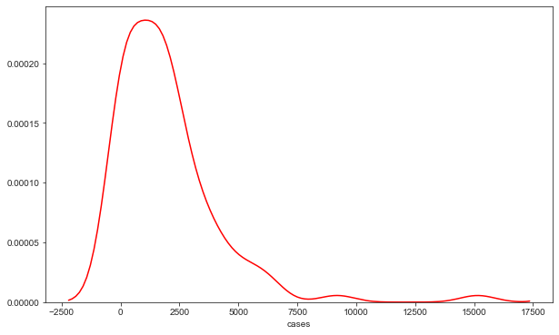

```python
asia = df_global_continent[df_global_continent.Continent == "Asia"]
sns.set_style('ticks')
fig, ax = plt.subplots()
fig.set_size_inches(10, 6)
sns.distplot(asia.cases, hist = False, color = "red", ax = ax)
```

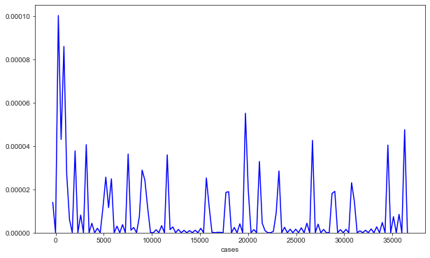

```python
na = df_global_continent[df_global_continent.Continent == "North America"]
sns.set_style('ticks')
fig, ax = plt.subplots()
fig.set_size_inches(10, 6)
sns.distplot(na.cases, hist = False, color = "blue", ax = ax)
```

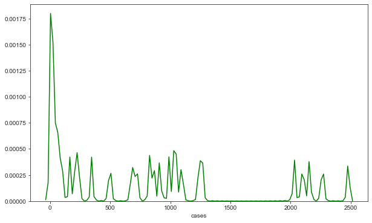

```python
sa = df_global_continent[df_global_continent.Continent == "South America"]
sns.set_style('ticks')
fig, ax = plt.subplots()
fig.set_size_inches(10, 6)
sns.distplot(sa.cases, hist = False, color = "green", ax = ax)
```

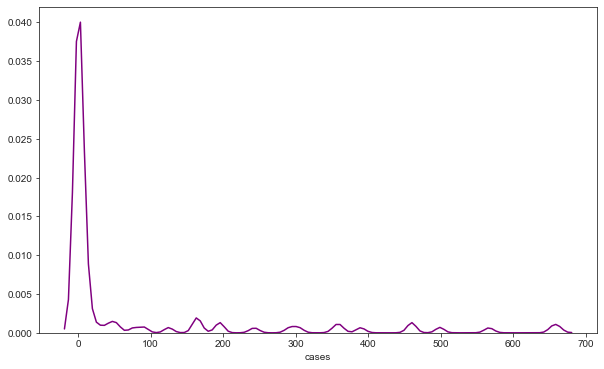

```python
australia = df_global_continent[df_global_continent.Continent == "Australia"]
sns.set_style('ticks')
fig, ax = plt.subplots()
fig.set_size_inches(10, 6)
sns.distplot(australia.cases, hist = False, color = "purple", ax = ax)
```

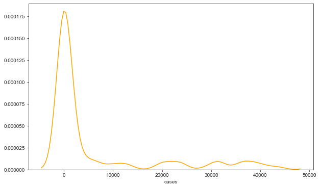

```python
europe = df_global_continent[df_global_continent.Continent == "Europe"]
sns.set_style('ticks')
fig, ax = plt.subplots()
fig.set_size_inches(10, 6)
sns.distplot(europe.cases, hist = False, color = "orange", ax = ax)
```